# Graunt’s Life Table Extended

coop711

2016-03-22

## Lifetable of J. Graunt

### Data

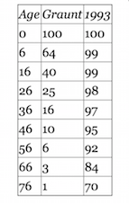

### Data Input

```r
graunt <- data.frame(x = c(0, 6, 16, 26, 36, 46, 56, 66, 76), lx.17th = c(100, 64, 40, 25, 16, 10, 6, 3, 1))
```

- 같은 연령대의 1993년 미국 생명표 입력

```r
us.93 <- data.frame(x = graunt$x, lx.93 = c(100, 99, 99, 98, 97, 95, 92, 84, 70))
```

- 두 자료를 합쳐서 하나의 데이터프레임으로

```r
graunt.us <- data.frame(graunt, lx.93 = us.93$lx)
graunt.us
```

```
##    x lx.17th lx.93
## 1  0     100   100
## 2  6      64    99
## 3 16      40    99
## 4 26      25    98
## 5 36      16    97
## 6 46      10    95
## 7 56       6    92
## 8 66       3    84
## 9 76       1    70
```

- Graunt 생명표로부터 개략의 생존함수 도시

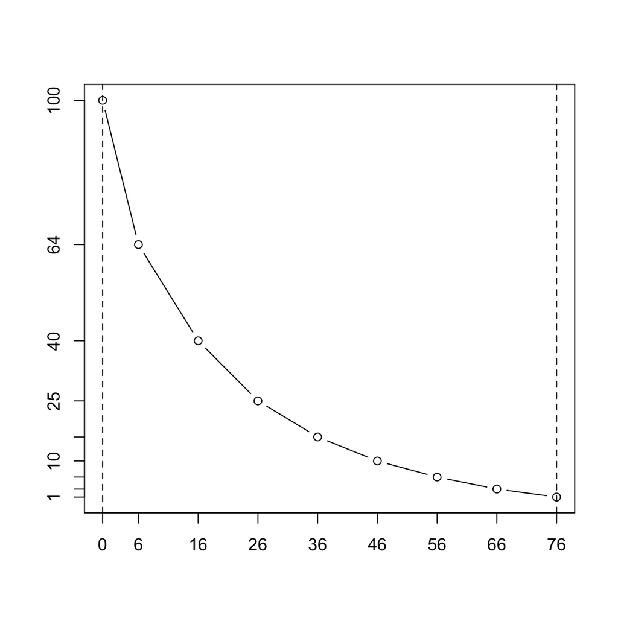

```r
plot(graunt$x, graunt$lx.17th, ann = F, xaxt = "n", yaxt = "n", type = "b")
axis(side = 1, at = graunt$x, labels = graunt$x)
axis(side = 2, at = graunt$lx.17th, labels = graunt$lx.17th)
abline(v = c(0, 76), lty = 2)
```

- 기대수명 파악이 용이하도록 빗금

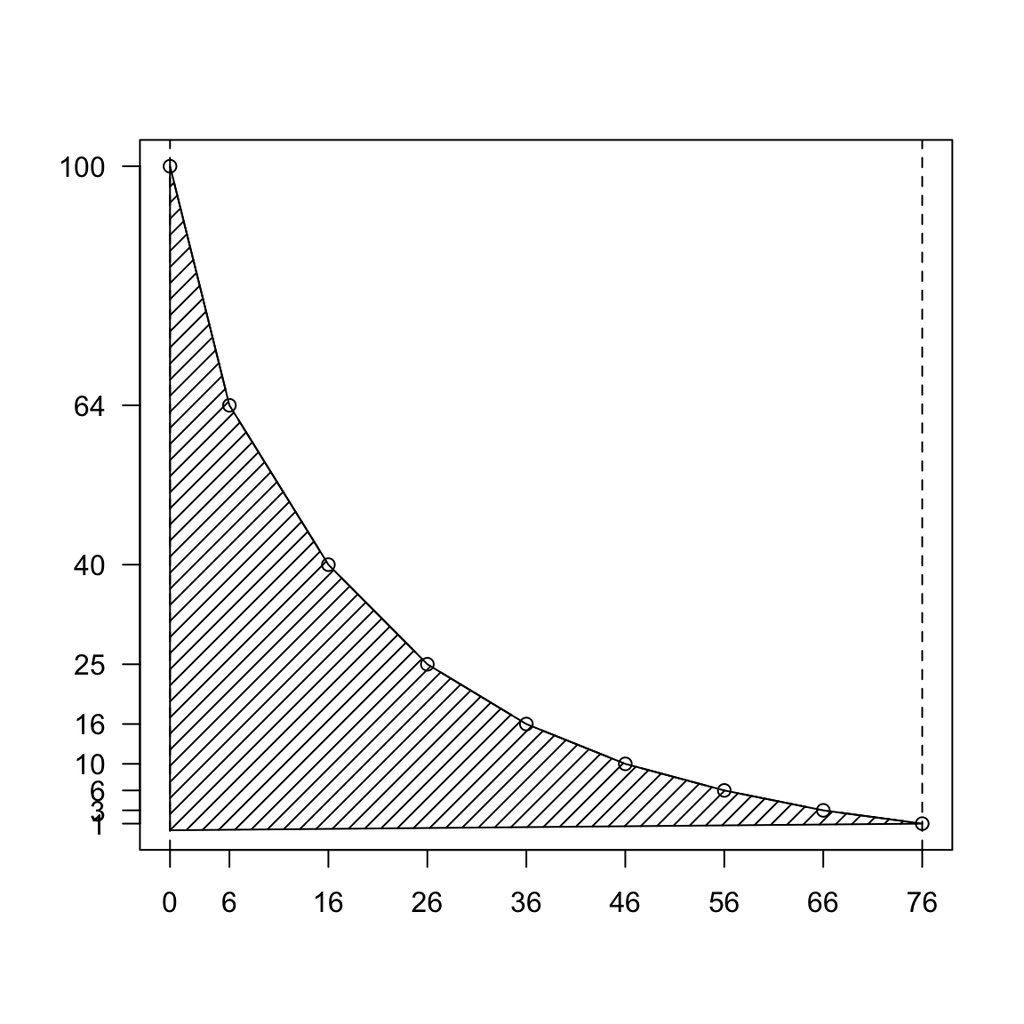

```r
plot(graunt$x, graunt$lx.17th, ann=F, xaxt="n", yaxt="n", type="b")
axis(side = 1, at = graunt$x, labels = graunt$x)
axis(side = 2, at = graunt$lx.17th, labels = graunt$lx.17th, las = 2)
abline(v = c(0, 76), lty = 2)
graunt.x <- c(graunt$x, 0)
graunt.y <- c(graunt$lx.17th, 0)
# graunt.x <- c(graunt$x, rev(graunt$x))
# graunt.y<-c(rep(0, length(graunt$x)), rev(graunt$lx.17th))
polygon(graunt.x, graunt.y, density = 15)
```

- 윤곽을 파악하기 쉽도록 격자 설정

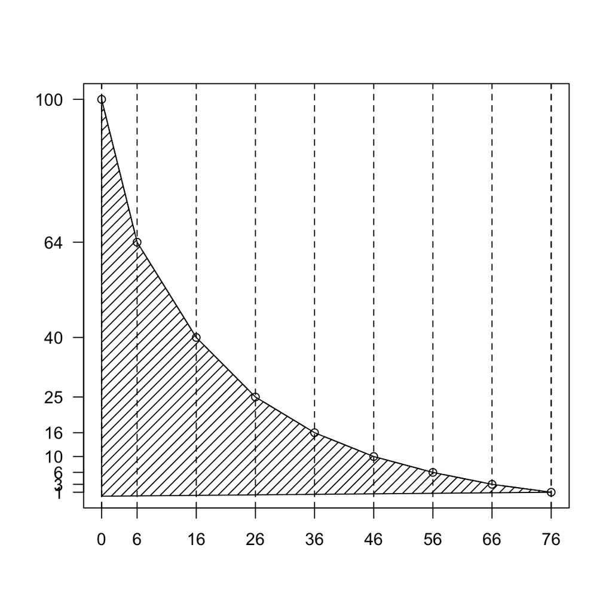

```r
plot(graunt$x, graunt$lx.17th, ann = F, xaxt = "n", yaxt = "n", type = "b")
axis(side = 1, at = graunt$x, labels = graunt$x)
axis(side = 2, at = graunt$lx.17th, labels = graunt$lx.17th, las = 2)
abline(v = c(0, 76), lty = 2)
graunt.x <- c(graunt$x, 0)
graunt.y <- c(graunt$lx.17th, 0)
polygon(graunt.x, graunt.y, density = 15)
abline(v = graunt$x, lty = 2)
```

- 메인 타이틀과 x축, y축 라벨 설정.

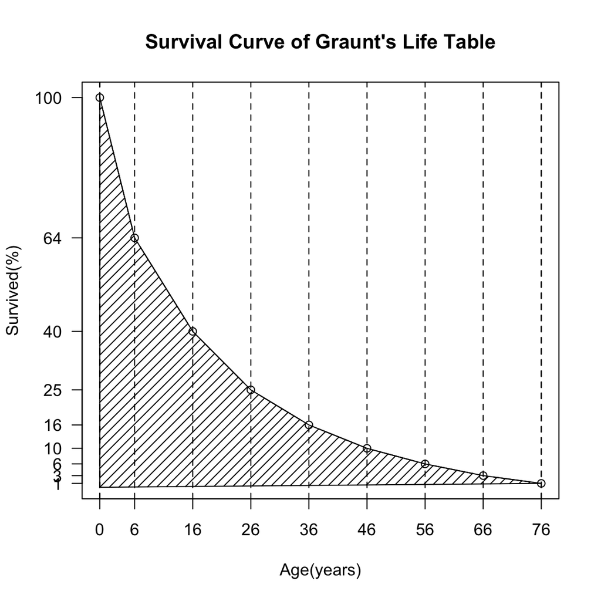

```r
# par(family = "Apple SD Gothic Neo")
plot(graunt$x, graunt$lx.17th, ann = F, xaxt = "n", yaxt = "n", type = "b")
axis(side = 1, at = graunt$x, labels = graunt$x)
axis(side = 2, at = graunt$lx.17th, labels = graunt$lx.17th, las = 2)
abline(v = c(0, 76), lty = 2)
graunt.x <- c(graunt$x, 0)
graunt.y <- c(graunt$lx.17th, 0)
polygon(graunt.x, graunt.y, density = 15)
abline(v = graunt$x, lty = 2)
# title(main = "John Graunt의 생존 곡선", xlab = "연령(세)", ylab = "생존률(%)")
title(main = "Survival Curve of Graunt's Life Table", xlab = "Age(years)", ylab = "Survived(%)")
```

## 1993년 미국의 생명표와 비교

- 1993년 미국의 생존함수와 비교하기 위하여 `lines()`에 `type = "b"`로 설정. $y$ 축의 70% 가 어떤 의미인지 음미할 것.

[figure not shown]

```r
plot(graunt$x, graunt$lx.17th, ann=F, xaxt="n", yaxt="n", type="b")
axis(side=1, at=graunt$x, labels=graunt$x)
axis(side=2, at=graunt$lx.17th, labels=graunt$lx.17th)
abline(v=c(0, 76), lty=2)
lines(us.93$x, us.93$lx.93, type="b")
axis(side=2, at=70, labels=70)
abline(h=70, lty=2)
text(x=66, y=95, labels="미국 1993년")
```

- Graunt의 생존곡선과 1993년 미국 생존곡선 사이의 빗금친 부분은 무엇을 상징하는가?

[figure not shown]

```r
plot(graunt$x, graunt$lx.17th, ann = F, xaxt = "n", yaxt = "n", type = "b")
axis(side = 1, at = graunt$x, labels = graunt$x)
axis(side = 2, at = graunt$lx, labels = graunt$lx.17th, las = 2)
abline(v = c(0, 76), lty = 2)
# lines(us.93$x, us.93$lx.93, type = "b")
lines(graunt$x, us.93$lx.93, type = "b")
axis(side=2, at=70, labels=70, las=1)
abline(h=70, lty=2)
graunt.x<-c(graunt$x, rev(graunt$x))
graunt.y<-c(rep(0, length(graunt$x)), rev(graunt$lx.17th))
us.y <- c(graunt$lx, rev(us.93$lx.93))
polygon(graunt.x, us.y, density=15, col="red", border=NA)
abline(v=graunt$x,lty=2)
title(main="Graunt와 1993년 미국의 생존 곡선", xlab="연령(세)", ylab="생존률(%)")
```

## ggplot 으로 그려본다면

- `graunt` 와 `us.93`를 하나의 데이터 프레임으로 통합

```r
graunt.us <- data.frame(graunt, lx.93 = us.93$lx.93)
graunt.us
```

```
##    x lx.17th lx.93
## 1  0     100   100
## 2  6      64    99
## 3 16      40    99
## 4 26      25    98
## 5 36      16    97
## 6 46      10    95
## 7 56       6    92
## 8 66       3    84
## 9 76       1    70
```

```r
str(graunt.us)
```

```
## 'data.frame':    9 obs. of  3 variables:
##  $ x      : num  0 6 16 26 36 46 56 66 76
##  $ lx.17th: num  100 64 40 25 16 10 6 3 1
##  $ lx.93  : num  100 99 99 98 97 95 92 84 70
```

- wide format을 long format으로 바꾸기 위해서 ‘reshape2’ 패키지 등록

```r
library(reshape2)
```

- `melt()` 함수의 사용법에 대하여 도움말 요청

```
?melt
```

- 다음 구조를 명확히 이해.

```r
graunt.melt<-melt(graunt.us, id.vars = "x", measure.vars = c("lx.17th", "lx.93"), value.name="lx")
graunt.melt
```

```
##     x variable  lx
## 1   0  lx.17th 100
## 2   6  lx.17th  64
## 3  16  lx.17th  40
## 4  26  lx.17th  25
## 5  36  lx.17th  16
## 6  46  lx.17th  10
## 7  56  lx.17th   6
## 8  66  lx.17th   3
## 9  76  lx.17th   1
## 10  0    lx.93 100
## 11  6    lx.93  99
## 12 16    lx.93  99
## 13 26    lx.93  98
## 14 36    lx.93  97
## 15 46    lx.93  95
## 16 56    lx.93  92
## 17 66    lx.93  84
## 18 76    lx.93  70
```

```r
str(graunt.melt)
```

```
## 'data.frame':    18 obs. of  3 variables:
##  $ x       : num  0 6 16 26 36 46 56 66 76 0 ...
##  $ variable: Factor w/ 2 levels "lx.17th","lx.93": 1 1 1 1 1 1 1 1 1 2 ...
##  $ lx      : num  100 64 40 25 16 10 6 3 1 100 ...
```

- 17세기 생명표와 1993년 생명표를 `times` factor로 구분

```r
graunt.melt$times <- factor(graunt.melt$variable, labels = c("17th", "1993"))
str(graunt.melt)
```

```
## 'data.frame':    18 obs. of  4 variables:
##  $ x       : num  0 6 16 26 36 46 56 66 76 0 ...
##  $ variable: Factor w/ 2 levels "lx.17th","lx.93": 1 1 1 1 1 1 1 1 1 2 ...
##  $ lx      : num  100 64 40 25 16 10 6 3 1 100 ...
##  $ times   : Factor w/ 2 levels "17th","1993": 1 1 1 1 1 1 1 1 1 2 ...
```

- `ggplot2` 패키지 등록

```r
library(ggplot2)
```

- ggplot의 구조를 이해하기 쉽도록 가능한 단계별로 작업하고 저장. `geom_polygon` 작업에서 `data.frame`과 `aes`가 바뀌므로 `ggplot()`을 비워놓은 점에 유의.

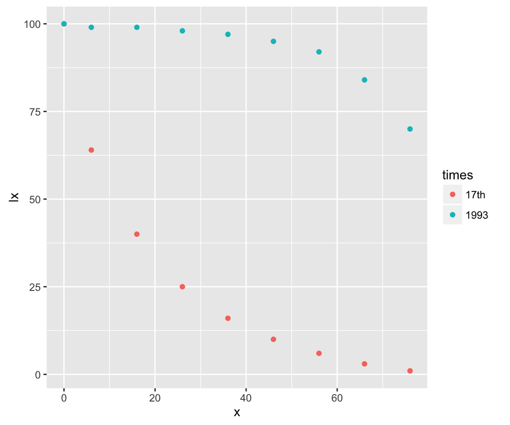

```r
g1 <- ggplot() + geom_point(data = graunt.melt, aes(x = x, y = lx, colour = times))
g1
```

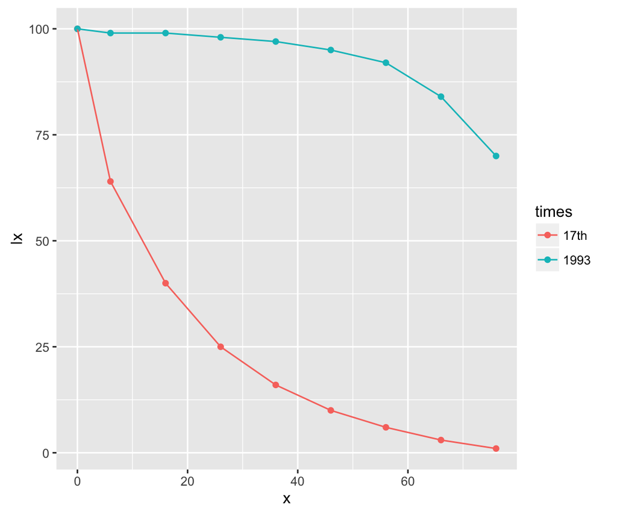

```r
g2 <- g1 + geom_line(data = graunt.melt, aes(x = x, y = lx, colour = times))
g2
```

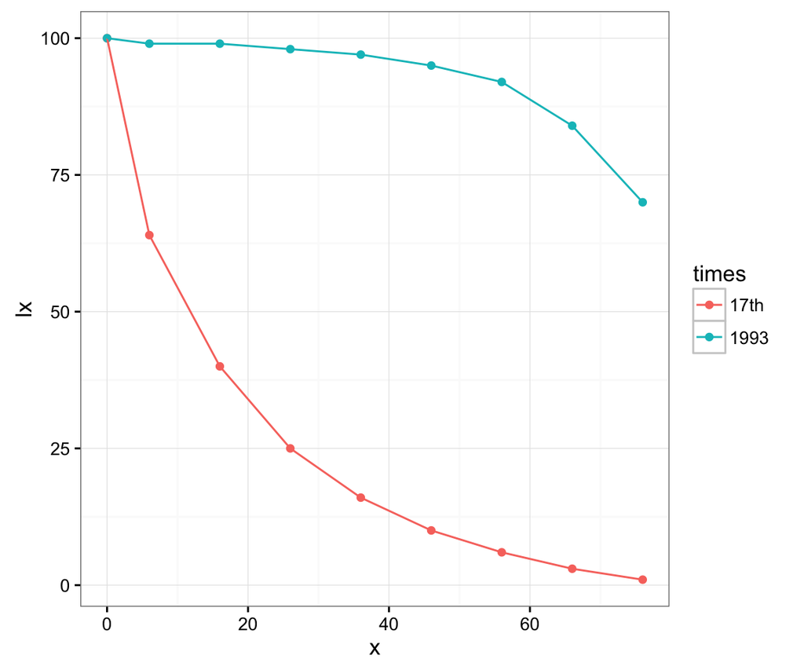

```r
g3 <- g2 + theme_bw()
g3
```

- polygon 으로 두 생명곡선의 차이를 드러내기 위해서는 polygon의 좌표를 나타내는 별도의 데이터 프레임이 필요함.

```r
graunt.poly <- data.frame(x = graunt.melt[c(1:9, 18:10), 1], y = graunt.melt[c(1:9, 18:10), 3])
graunt.poly
```

```
##     x   y
## 1   0 100
## 2   6  64
## 3  16  40
## 4  26  25
## 5  36  16
## 6  46  10
## 7  56   6
## 8  66   3
## 9  76   1
## 10 76  70
## 11 66  84
## 12 56  92
## 13 46  95
## 14 36  97
## 15 26  98
## 16 16  99
## 17  6  99
## 18  0 100
```

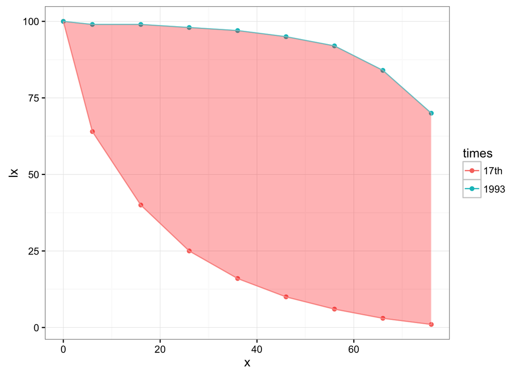

```r
g4 <- g3 + geom_polygon(data = graunt.poly, aes(x=x, y=y), alpha=0.3, fill="red")
g4
```

#### Starting with a different plot

- 점들을 선으로 이어주기 위하여 `geom_line()`를 사용하면 원하지 않는 결과를 얻게 됨. `geom_path()`를 사용하여야 함.

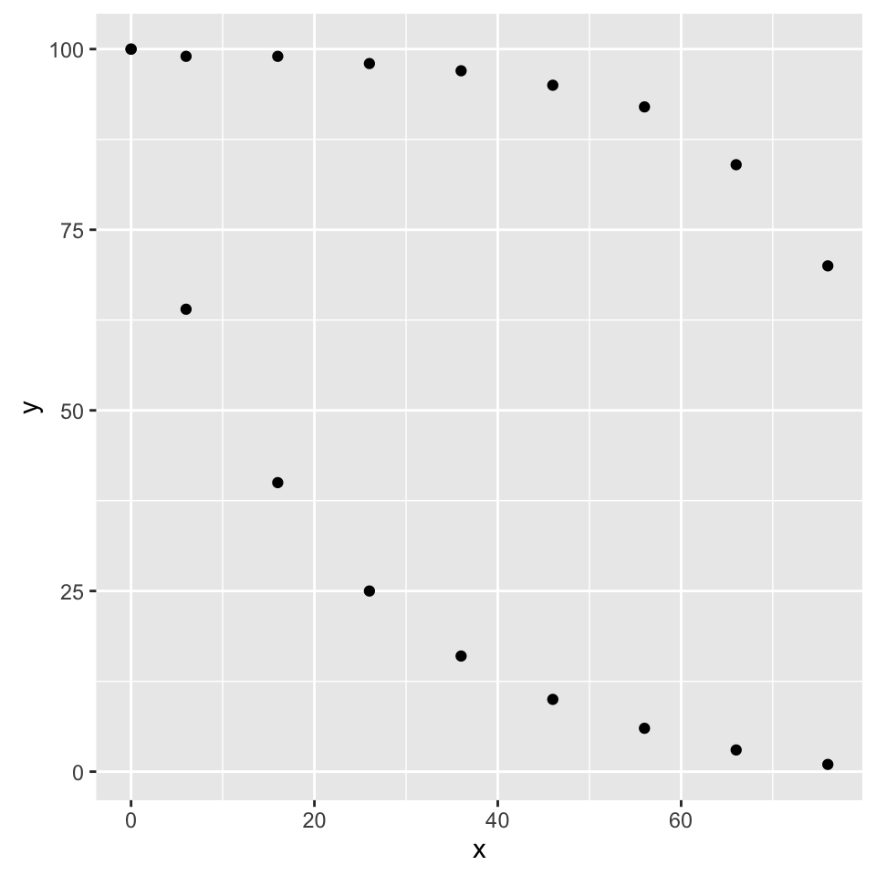

```r
p1 <- ggplot(graunt.poly, aes(x=x, y=y)) + geom_point()
p1
```

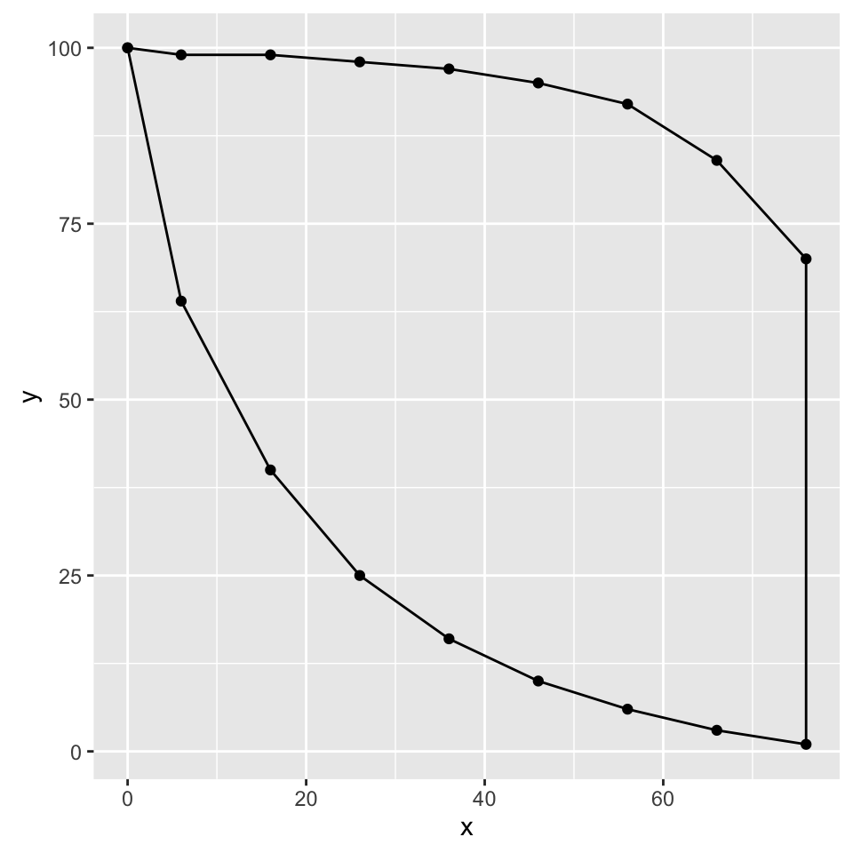

```r
p2 <- p1 + geom_path()
p2
```

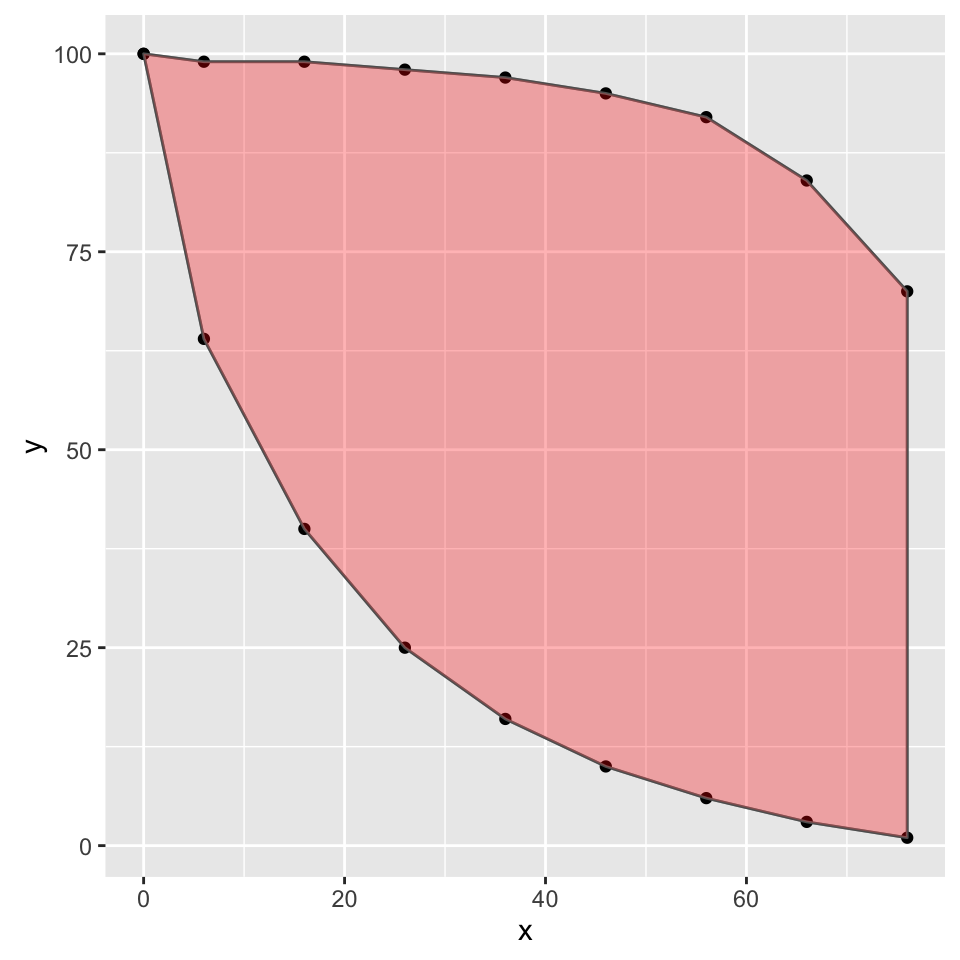

```r
p3 <- p2 + geom_polygon(alpha = 0.3, fill="red")
p3
```

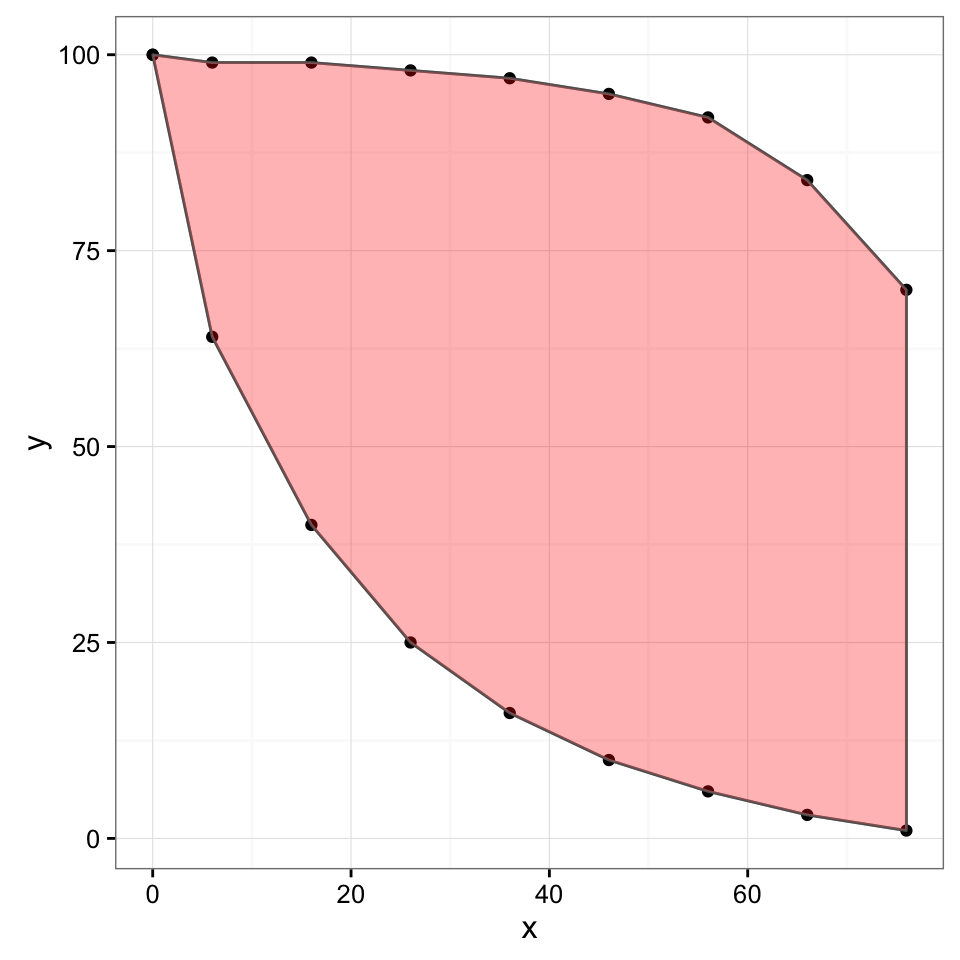

```r
p4 <- p3 + theme_bw()
p4
```

- 타이틀과 자막에 한글을 넣는 방법은 다음 시간에^^